# Probability Distributions and Statistical Concepts

## Overview

This section delves into the fundamental concepts and applications of probability distributions, key statistical theorems, and methods for analyzing random variables. We aim to build a foundational understanding, enriched by practical examples and real-world applications.

## Understanding and Applying Common Probability Distributions

### Binomial, Poisson, and Normal Distributions

- The **Binomial Distribution** is applicable when modeling the number of successes in a fixed number of independent trials. For example, predicting the number of heads in 10 coin tosses or determining the probability of a certain number of defective items in a batch.
- The **Poisson Distribution** is ideal for modeling the number of events in a fixed interval of time or space when these events happen with a known constant rate. It’s used for things like counting the number of calls at a call center over an hour or the arrival of buses at a station.
- The **Normal Distribution** is a crucial tool in statistics, representing data that clusters around a mean or average. It is the basis for many statistical tests and is used to model everything from heights and test scores to measurement errors.

**Let’s look at these distributions in action with R:**

```r
# Binomial example: Probability of exactly 6 heads in 10 fair coin tosses
print(dbinom(6, size=10, prob=0.5))
```

```
## [1] 0.2050781
```

```r
# Poisson example: Probability of receiving 3 emails in an hour if the average rate is 5 emails per hour
print(dpois(3, lambda=5))
```

```
## [1] 0.1403739
```

```r
# Normal distribution example: Probability density of a score at the mean of a distribution
print(dnorm(0, mean=0, sd=1))
```

```
## [1] 0.3989423
```

### Continuous vs Discrete Distributions

- **Continuous distributions** are used for data that can take any value within an interval. Measurements like weight, temperature, and distance, where data can vary continuously, are modeled using continuous distributions.
- **Discrete distributions** are used for countable data. Whenever you count something, like the number of students in a class or the number of cars in a parking lot, you are working with discrete data.

**Here’s how you might visualize these differences with R:**

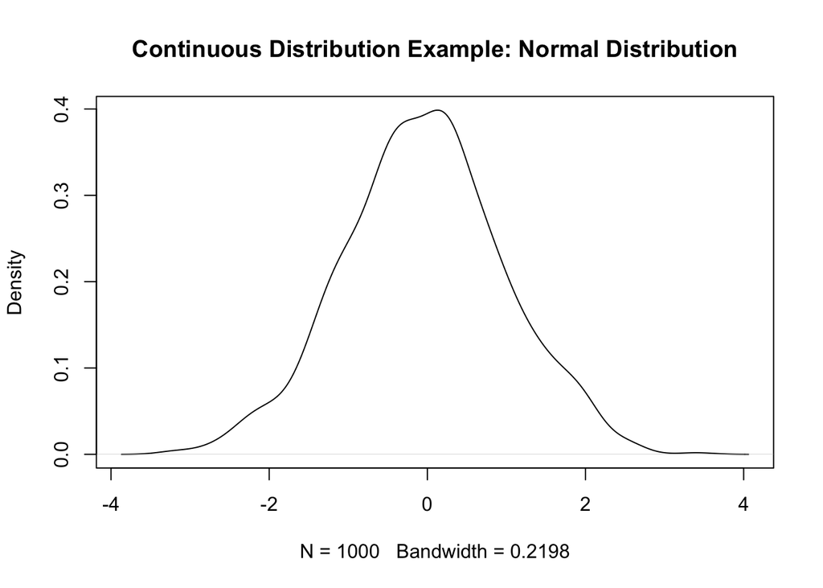

```r
# Continuous distribution visualization
plot(density(rnorm(1000)), main="Continuous Distribution Example: Normal Distribution")
```

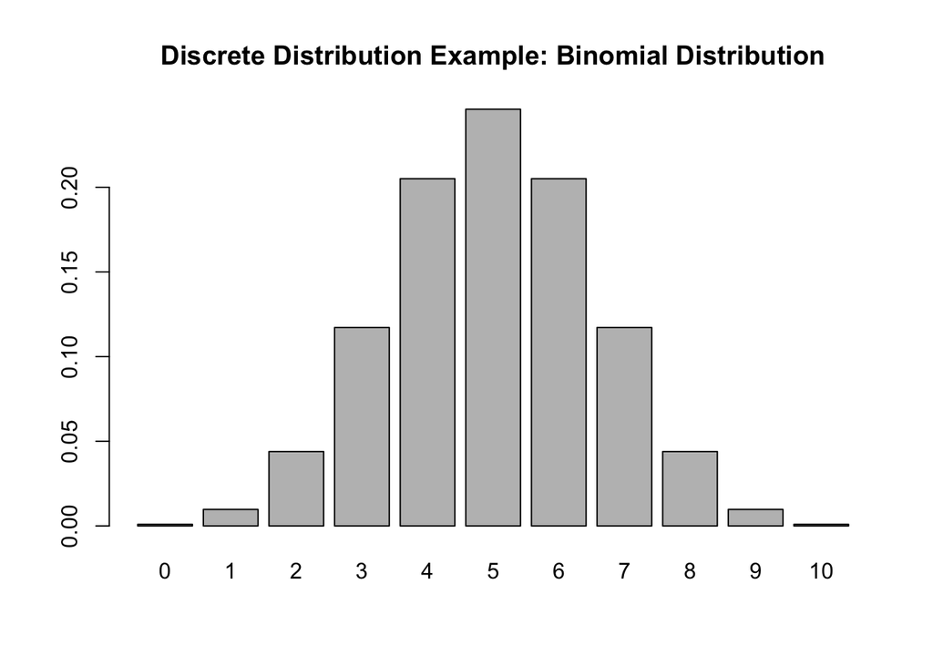

```r
# Discrete distribution visualization
barplot(dbinom(0:10, size=10, prob=0.5), names.arg=0:10, main="Discrete Distribution Example: Binomial Distribution")
```

### The Central Limit Theorem (CLT)

- A cornerstone of statistics, the CLT states that the distribution of sample means approximates a normal distribution as the sample size becomes large, regardless of the population distribution’s shape. This theorem underpins many statistical methods, including hypothesis testing and the creation of confidence intervals.

**Experience the CLT through a simple R simulation:**

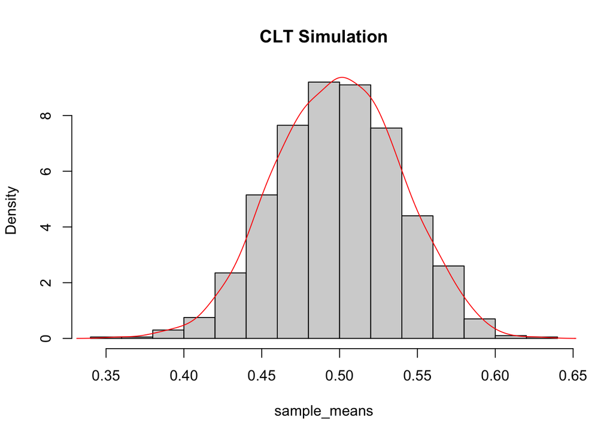

```r
# Simulating sample means
sample_means <- replicate(1000, mean(runif(50, min=0, max=1)))
hist(sample_means, probability=TRUE, main="CLT Simulation")
lines(density(sample_means), col="red")
```

# Exploring Random Variables and Expected Values

## Objective

The goal of this section is to delve into the statistical fundamentals of random variables and expected values, elaborating on their theoretical underpinnings, methods of calculation, and practical implications in data analysis.

### Defining and Calculating Expected Values

- **Definition**: The expected value of a random variable gives a measure of the center of the distribution of the variable. Essentially, it is the long-term average value of the variable when the experiment it represents is repeated infinitely many times.
- **Formula**: For a discrete random variable $X$ with possible values $x_1, x_2, ..., x_n$ and probabilities $p_1, p_2, ..., p_n$, the expected value $E(X)$ is calculated as:
  $$E(X) = \sum_{i=1}^{n} x_i p_i$$
- **Calculation Example**: Consider a simple dice roll where each face is equally likely. The expected value of the dice roll can be computed as follows:

  ```r
  values <- 1:6
  probabilities <- rep(1/6, 6)
  expected_value <- sum(values * probabilities)
  print(paste("Expected Value of a Dice Roll:", expected_value))
  ```

  ```
  ## [1] "Expected Value of a Dice Roll: 3.5"
  ```

### Variance and Standard Deviation of Random Variables

- **Variance**: Measures the spread of the random variable from its expected value, quantifying the average squared deviations from the mean. It is represented mathematically as:
  $$\text{Var}(X) = E[(X - \mu)^2]$$
- **Standard Deviation**: The square root of the variance, providing a measure of spread that is in the same units as the data.
- **Demonstration**:

  ```r
  # Continuing with the dice example
  mean_dice <- mean(values)
  variance_dice <- sum((values - mean_dice)^2 * probabilities)
  sd_dice <- sqrt(variance_dice)
  print(paste("Variance of Dice Roll:", variance_dice))
  ```

  ```
  ## [1] "Variance of Dice Roll: 2.91666666666667"
  ```

  ```r
  print(paste("Standard Deviation of Dice Roll:", sd_dice))
  ```

  ```
  ## [1] "Standard Deviation of Dice Roll: 1.70782512765993"
  ```

### The Law of Large Numbers

- **Explanation**: This fundamental theorem states that as the number of trials in a random experiment increases, the average of the results obtained should get closer to the expected value. It forms the basis for frequency-based probability.
- **Practical Implications**: Demonstrates that empirical probabilities converge to theoretical probabilities as the number of trials increases, which is critical for simulations and practical estimations in statistics.
- **Demonstration**:

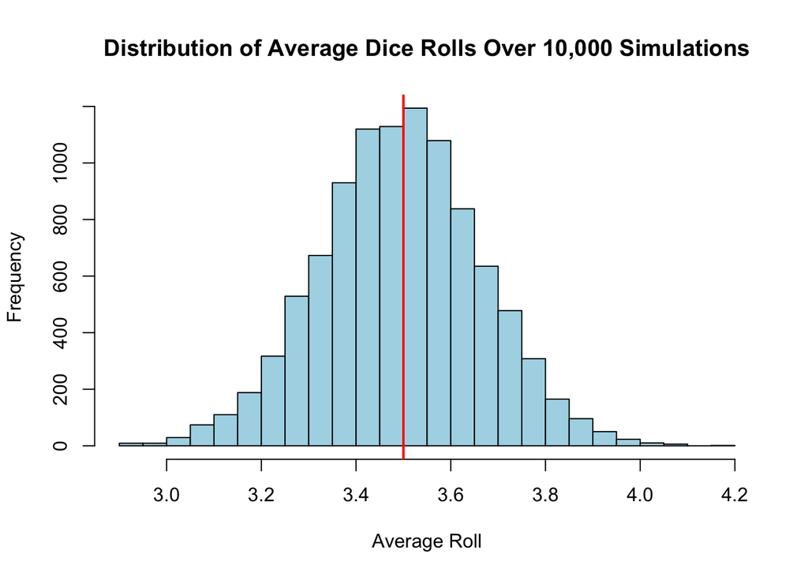

  ```r
  # Simulating repeated dice rolls
  set.seed(123)  # For reproducibility
  rolls <- replicate(10000, mean(sample(values, 100, replace=TRUE)))
  hist(rolls, breaks=30, main="Distribution of Average Dice Rolls Over 10,000 Simulations",
       xlab="Average Roll", ylab="Frequency", col="lightblue")
  abline(v=expected_value, col="red", lwd=2)
  ```

# Practical Applications and Demonstrations of Statistical Concepts

## Introduction

This section is designed to transition from theoretical understanding to practical application, allowing students to apply statistical concepts to real-world data. Through hands-on activities, we aim to deepen comprehension and enhance analytical skills, preparing students for real-world challenges.

## Engaging with Simulations: Understanding Through Action

### Simulating Statistical Distributions

- **Objective**: Experience firsthand the properties and behaviors of different statistical distributions.
- **Activity**:
  - Generate data samples from binomial, Poisson, and normal distributions.
  - Analyze the shape and spread of these distributions under various parameters to observe theoretical properties in practice.

  **Example: Simulating a Normal Distribution**

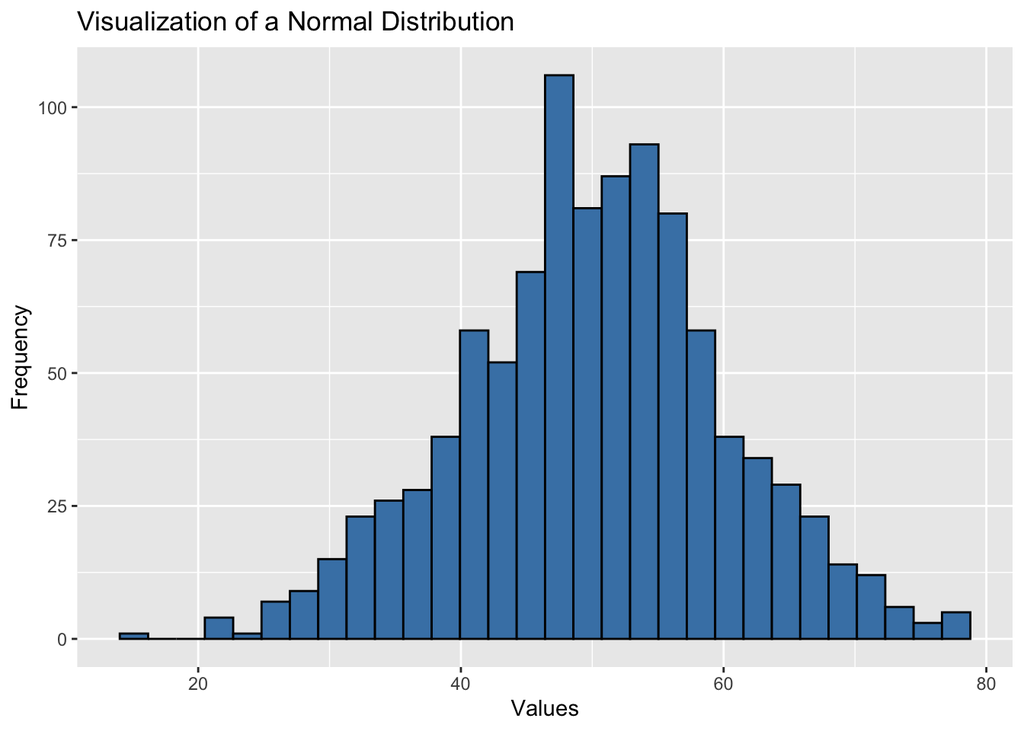

  ```r
  # Generate a sample from a normal distribution
  sample_normal <- rnorm(1000, mean = 50, sd = 10)

  # Visualize the distribution
  library(ggplot2)
  ggplot(data.frame(Value = sample_normal), aes(x = Value)) +
    geom_histogram(bins = 30, fill = 'steelblue', color = 'black') +
    labs(title = "Visualization of a Normal Distribution", x = "Values", y = "Frequency")
  ```

### Visual Insights: Plotting Distributions

- **Objective**: Cultivate the ability to visually interpret statistical data through plotting.
- **Activity**:
  - Use R to create dynamic visualizations (histograms, density plots) that illustrate the distribution of data.
  - Discuss how visualization aids in understanding data distributions and identifying outliers or patterns.

## Analyzing Data: From Theory to Practice

### Data-Driven Decision Making

- **Objective**: Apply statistical analysis to derive meaningful insights and make informed decisions.
- **Activity**:
  - Conduct a detailed analysis of a dataset by calculating descriptive statistics, applying probability distributions, and testing hypotheses.
  - Interpret the results to make decisions or predictions based on data.

  **Example: Sales Data Analysis**

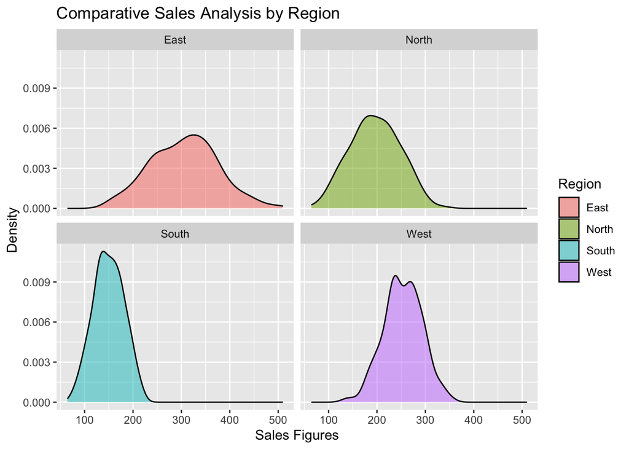

  ```r
  # Dataset preparation
  sales_data <- data.frame(
      Region = rep(c("North", "South", "East", "West"), each = 250),
      Sales = c(rnorm(250, mean = 200, sd = 50), rnorm(250, mean = 150, sd = 30),
                rnorm(250, mean = 300, sd = 70), rnorm(250, mean = 250, sd = 40))
  )

  # Analysis with ggplot2
  ggplot(sales_data, aes(x = Sales, fill = Region)) +
      geom_density(alpha = 0.5) +
      facet_wrap(~Region) +
      labs(title = "Comparative Sales Analysis by Region", x = "Sales Figures", y = "Density")
  ```

  ```r
  # Descriptive statistics
  library(dplyr)
  summary_stats <- sales_data %>%
      group_by(Region) %>%
      summarise(Mean = mean(Sales), SD = sd(Sales), .groups = 'drop')
  print(summary_stats)
  ```

  ```
  ## # A tibble: 4 × 3
  ##   Region  Mean    SD
  ##   <chr>  <dbl> <dbl>
  ## 1 East    306.  69.3
  ## 2 North   196.  51.4
  ## 3 South   150.  31.2
  ## 4 West    253.  39.5
  ```

This section not only reinforces statistical concepts through practical applications but also cultivates skills in data visualization and analysis. By engaging with real datasets and simulations, students enhance their ability to interpret and analyze data effectively, preparing them for professional roles that demand strong analytical capabilities.